# hw_4

Colby S.

2022-06-08

HW 4 ECP – 3004 (Summer 2022) Due: 06/16/2022 Berk & DeMarzo: Chapter 6

Problems 1-4, 10, 13, 17-19, 28

### 8-1. done

A 30-year bond with a face value of 1000 has a coupon rate of 5.5%, with semiannual payments. a. What is the coupon payment for this bond?
$$CPN = \frac{\text{Coupon Rate}*\text{Face
Value}}{\text{Number of Coupons per Year}}$$

```r
CPN <- 1000*5.5*0.01/2
CPN
```

```
## [1] 27.5
```

2. Draw the cash flows for the bond on a timeline.

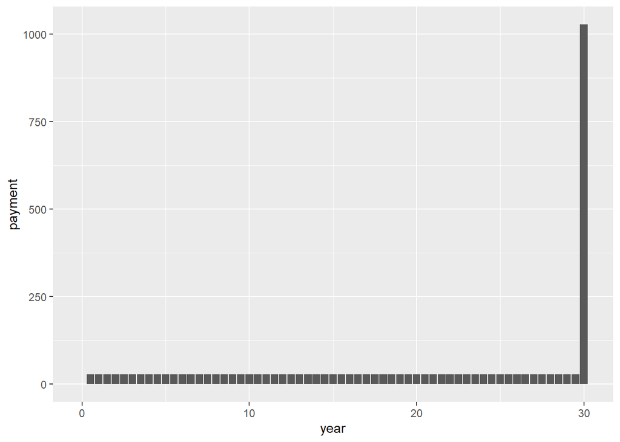

```r
year <- seq(from = 0, to = 30, by =0.5) #all the periods in the lifetime of the bond

payment <- rep(CPN, length(year)) #all coupon payments. first and last are incorrect
payment[length(payment)] <- CPN+1000 # last payment
payment[1] <- 0 #first payment

data.frame(year, payment) |>
  ggplot()+
  geom_col (aes(x = year, y = payment))
```

### 8-2. done

Assume that a bond will make 20 dollar payments every six months for 20 periods, and when it expires it will pay out an additional 1000 dollars

```r
CPN <- 20 #dollars
face_value <- 1000 #dollars
coupons_per_year <- 2 #semiannual
maturity_periods <- 20 #maturity in periods
```

1. What is the maturity of the bond (in years)?

> the maturity, or term, of the bond is the remaining time until the bond reaches maturity. In this case we convert 20 six month periods into years.

```r
6*20/12 #years
```

```
## [1] 10
```

2. What is the coupon rate (in percent)?
   $$CPN = \frac{\text{Coupon Rate} * \text{Face
   Value}}{\text{Number of Coupons per Year}}$$

```r
coupon_rate <- CPN *coupons_per_year / face_value
coupon_rate
```

```
## [1] 0.04
```

3. What is the face value?

```r
face_value #given in problem
```

```
## [1] 1000
```

### 8-3. done

The following table summarizes prices of various default-free, zero-coupon bonds (expressed as a percentage of face value):

```
##           [,1]  [,2]  [,3]  [,4]  [,5]
## maturity  1.00  2.00  3.00  4.00  5.00
## price    95.51 91.05 86.38 81.65 76.51
```

1. Compute the yield to maturity for each bond.

> because the bonds are zero-coupon bonds, the present value of the bond is the discounted future value of the bond.

$$PV = \frac{FV}{\text{yeild to maturity
(YTM)}^n}$$

```r
YTM <- round((100/price)^(1/maturity) - 1, digits = 3)
YTM
```

```
## [1] 0.047 0.048 0.050 0.052 0.055
```

2. Plot the zero-coupon yield curve (for the first five years).

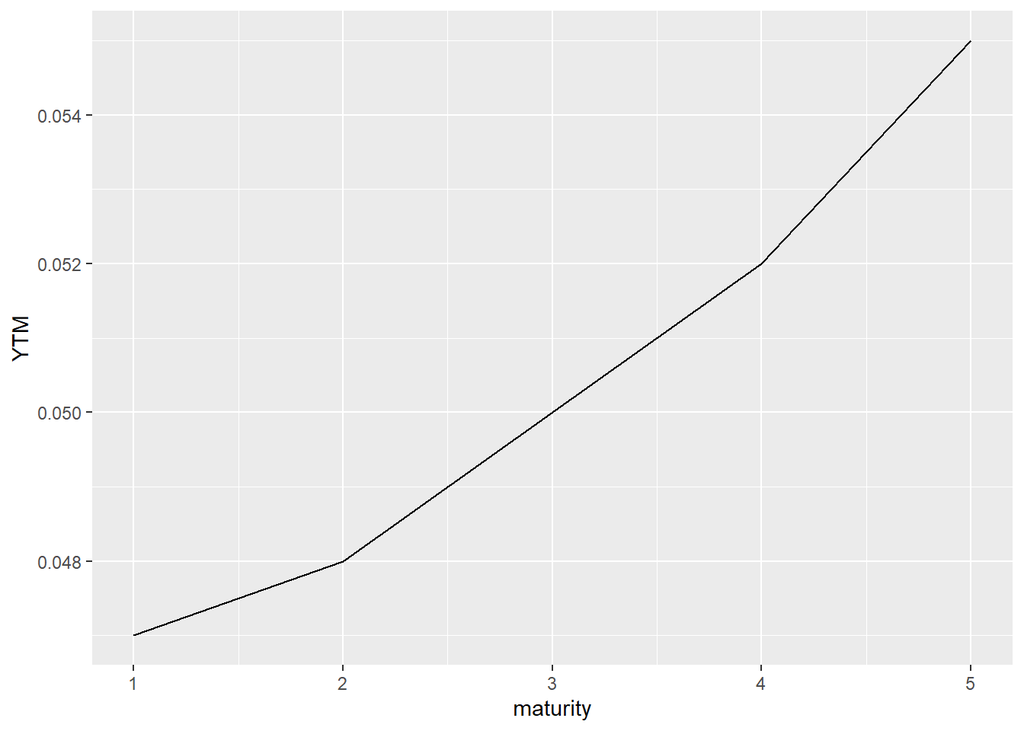

```r
data.frame(maturity, YTM) |>
ggplot(aes(x = maturity, y = YTM)) +
  geom_line()
```

3. Is the yield curve upward sloping, downward sloping, or flat?

> upword sloping

### 8-4. done

Suppose the current zero-coupon yield curve for risk-free bonds is as follows:

```
##          [,1]  [,2]   [,3]   [,4]   [,5]
## maturity 1.00 2.000 3.0000 4.0000 5.0000
## YTM      0.05 0.055 0.0575 0.0595 0.0605
```

$$CPN = \frac{\text{Coupon Rate * Face
Value}}{\text{Coupons per Year}}$$
$$PV = FV/(1+r)^n$$
a. What is the price per 100 face value of a two-year, zero-coupon, risk-free bond? b. What is the price per 100 face value of a four-year, zero-coupon, risk-free bond? c. What is the risk-free interest rate for a five-year maturity?

```r
n <- c(2, 4, 5)
solutions <- 100/(1+YTM[n])^n
names(solutions) <- c("a", "b", "c")
solutions
```

[output not shown]

### 8-10. done

Suppose a seven-year, 1000 bond with an 8% coupon rate and semiannual coupons is trading with a yield to maturity of 6.75%.

```r
term <- 7 #years
face_value <- 1000 #dollars
coupon_rate <- 0.08
periods_per_year <- 2 #semiannual
YTM <- 0.0675
```

1. Is this bond currently trading at a discount, at par, or at a premium? Explain. > a bond traving above par will have a price > face value. This occurs when the coupon rate > YTM > a bond trading at par will have a price = face value. This occurs when the coupon rate = YTM > a bond trading below par will have a price < face value. This occurs when teh coupon rate is < YTM

> this bond is trading at a premium because the coupon rate > YTM
2. If the yield to maturity of the bond rises to 7% (APR with semiannual compounding), what price will the bond trade for?
   $$\text{(6.5) Yeild to Maturity of a Coupon
   Bond}$$
   $$price =
   \frac{CPN}{y}(1-\frac{1}{(1+y)^n}) + \frac{\text{Face
   Value}}{(1+y)^n}$$

```r
YTM <- 0.07 #APR
y <- YTM/periods_per_year
n <- term * periods_per_year # compounding periods left on bond
CPN <- coupon_rate*face_value / periods_per_year

CPN/y*(1-1/(1+y)^n) + face_value/(1+y)^n
```

```
## [1] 1054.603
```

### 8-13. done

Consider the following $100 annual bonds:

```
##   bond coupon_rate maturity face_value CPN
## 1    A        0.00       15        100   0
## 2    B        0.00       10        100   0
## 3    C        0.04       15        100   4
## 4    D        0.08       10        100   8
```

1. What is the percentage change in the price of each bond if its yield to maturity falls from 6% to 5%?
   $$\text{(6.5) Yeild to Maturity of a Coupon
   Bond}$$
   $$price =
   \frac{CPN}{y}(1-\frac{1}{(1+y)^n}) + \frac{\text{Face
   Value}}{(1+y)^n}$$

$$\text{percentage change} = \frac{\Delta
price}{price_\text{original}}*100$$

```r
term <- maturity #the bonds are new, so the term is the full term of the bond (maturity)

pct_change_df <- bond_df |>
  mutate(price_5 = CPN/0.05*(1-1/(1+0.05)^term) + face_value/(1+0.05)^term, #price with YTM = 5%
         price_6 = CPN/0.06*(1-1/(1+0.06)^term) + face_value/(1+0.06)^term, #price with YTM = 6%
         percent_change = round((price_5 - price_6)/price_6*100, 2)) |>
  select(bond, percent_change)

# there is a more concise way to program this
# YTM <- c(0.06, 0.05)
# bond_df |>
#   mutate(percent_change = diff(CPN/YTM*(1-1/(1+YTM)^term) + face_value/(1+YTM)^term), #price with YTM = 5%
#          price_6 = CPN/0.06*(1-1/(1+0.06)^term) + face_value/(1+0.06)^term) #price with YTM = 6%
```

2. Which of the bonds A–D is most sensitive to a 1% drop in interest rates from 6% to 5% and why? Which bond is least sensitive? Provide an intuitive explanation for your answer.

```r
pct_change_df[which.max(pct_change_df$percent_change), ]
```

```
##   bond percent_change
## 1    A          15.28
```

```r
pct_change_df[which.min(pct_change_df$percent_change), ]
```

```
##   bond percent_change
## 4    D           7.36
```

### 8-17.

What is the price today of a two-year, default-free security with a face value of $1000 and an annual coupon rate of 6%? Does this bond trade at a discount, at par, or at a premium?

```r
term <- 2 #years
face_val <- 1000 #dollars
coupon_rate <- 0.06 #6%
```

> A bond trades at a premium when the price > face value. This occurs when the coupon rate > YTM.

### 8-18.

What is the price of a five-year, zero-coupon, default-free security with a face value of 1000?

### 8-28.

Grummon Corporation has issued zero-coupon corporate bonds with a five-year maturity. Investors believe there is a 25% chance that Grummon will default on these bonds. If Grummon does default, investors expect to receive only 65 cents per dollar they are owed. If investors require a 6% expected return on their investment in these bonds, what will be the price and yield to maturity on these bonds?